# Análisis de Series Temporales

Tabajo Práctico N° 2

Couste, Ciro; Gir, Alberto; Menzella, Carla; Misaña, Agostina; Viera, Arnaldo

Diciembre de 2021

# Resumen ejecutivo:

El presente trabajo tiene como objetivo poner en práctica los conocimientos adquiridos en la materia Análisis de Series temporales de la Maestría en Ciencia de Datos de la Universidad Austral. Para ello analizaremos dos series de temporales. La primera es la cantidad de noches que los viajeros no residentes pernoctan en un complejo hotelero dentro de Argentina. Y la segunda serie es la variación porcentual del índice de precios al consumidor de la república Argentina. A diferencia del primer práctico decidimos utilizar la segunda serie en variación porcentual y no en níveles porque pensamos que más allá del nivel de precios, lo importante es analizar la inflación. Y debido al aprendizaje realizado en el primer práctico, pudimos observar que a medida que la serie incrementaba el valor de los niveles de precios se incrementaba el valor de la variación. Dicho dato pierde referencia si no lo comparamos en términos porcentuales. Ejemplificando, una inflación mensual del 2% es comparable en terminos de impacto económico con otro punto en la serie donde haya dado un valor similar, aunque si partimos de niveles de precios diferentes la variación en términos absolutos también será diferente.

# Introducción:

Analizaremos las dos series por separado. Para cada una de ellas verificaremos el estado estacionario de las mismas, con diferentes tests de raíces unitarias. En caso de ser necesario aplicaremos las transformaciones necesarias para llegar a la estacionaridad. Luego representaremos las mismas a través de modelos ARIMA o SARIMA según corresponda. Para ello es importante detectar si las series de tiempo tienen un comportamiento cíclico. Una vez representadas estudiaremos el comportamiento de los residuos del modelos para determinar si se comportan como un ruido blanco. O si por el contrario precisan transformaciones.

# Desarrollo

## Serie de tiempo 1:

Se Importa el datasets y configura como serie de tiempo:

```r
data1 %>%
  mutate(pernoctes_no_residentes) %>%
  head(4) %>%
  gt() %>%
  tab_header('Cantidad de noches de los viajeros no residentes en los establecimientos hoteleros y parahoteleros del pais')
```

Cantidad de noches de los viajeros no residentes en los establecimientos hoteleros y parahoteleros del pais

| indice_tiempo | pernoctes_no_residentes |
| --- | --- |
| 2007-01-01 | 1072117 |
| 2007-02-01 | 1102004 |
| 2007-03-01 | 947343 |
| 2007-04-01 | 821359 |

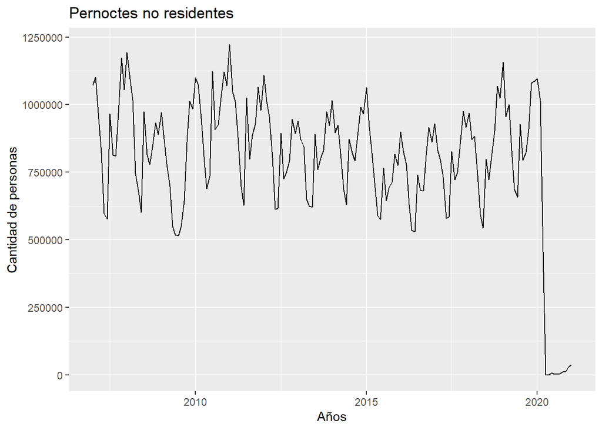

```r
autoplot(SdT1,
         main = "Pernoctes no residentes",
         ylab = "Cantidad de personas",
         xlab = "Años")
```

En el grafico de SdT1 se observa un comportamiento aparentemente estacional. Hasta 2020, no se observa ninguna tendencia clara a crecer o decrecer. Se ve una fuerte caida a inicios de 2020,lo cual se puede pensar que fue por el inicio de la pandemia. Se procede a graficar la descomposicion:

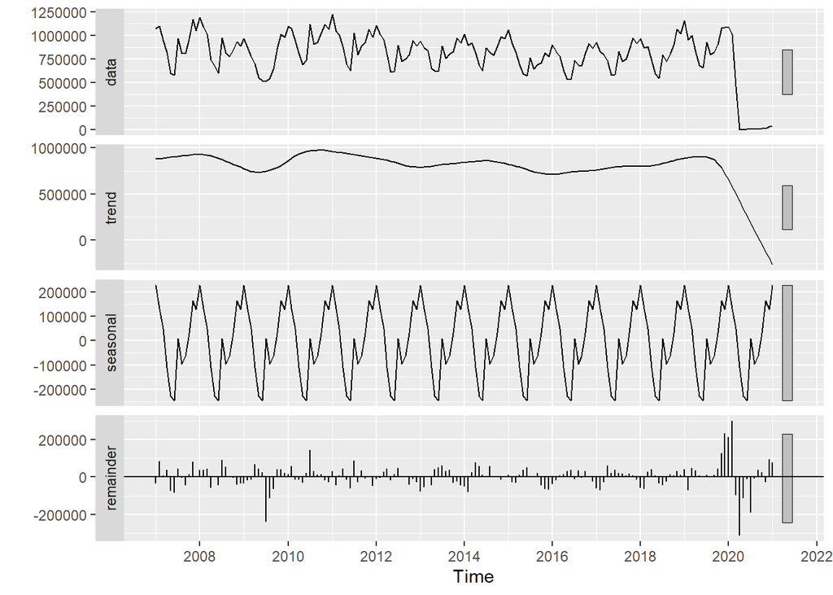

```r
autoplot(stl(SdT1, s.window = "periodic"), ts.colour="blue" )
```

Se observa un componente de ciclos (seasonal), sin tendencia aparente hasta que decrece en 2020. Se puede pensar en las diversas cuarentenas implementadas por los gobiernos a raíz de la pandemia por Covid 19 como un suceso extremo u outlier. Para ello es interesante poder observar la serie solo hasta diciembre de 2019.

Por lo tanto se construye la serie sin el año 2020:

```r
SdT1sinout <- ts (data11$pernoctes_no_residentes,
              frequency = 12,
              start = c(2007,1),
              end = c(2019,12))

data.class(SdT1sinout)
```

```
## [1] "ts"
```

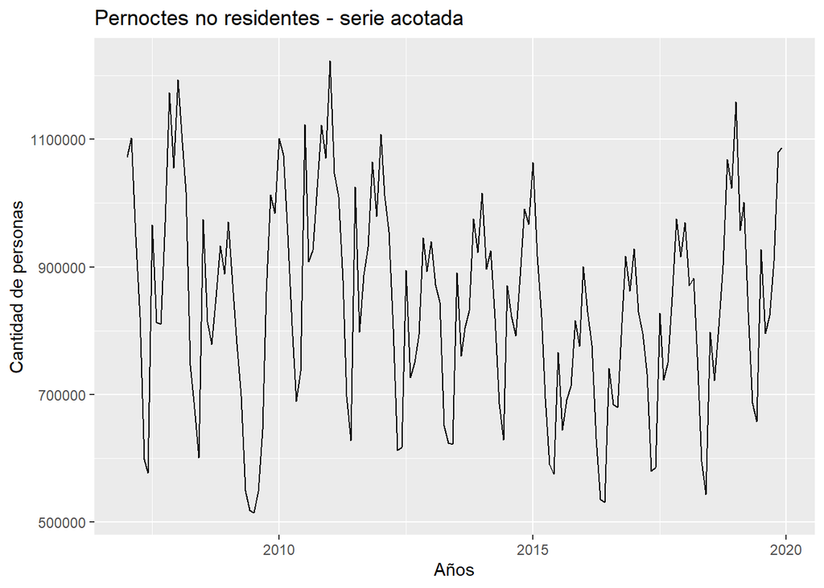

```r
autoplot(SdT1sinout,
         main = "Pernoctes no residentes - serie acotada",
         ylab = "Cantidad de personas",
         xlab = "Años")
```

Se procede a graficar la descomposicion nuevamente con el rango la serie ajustado:

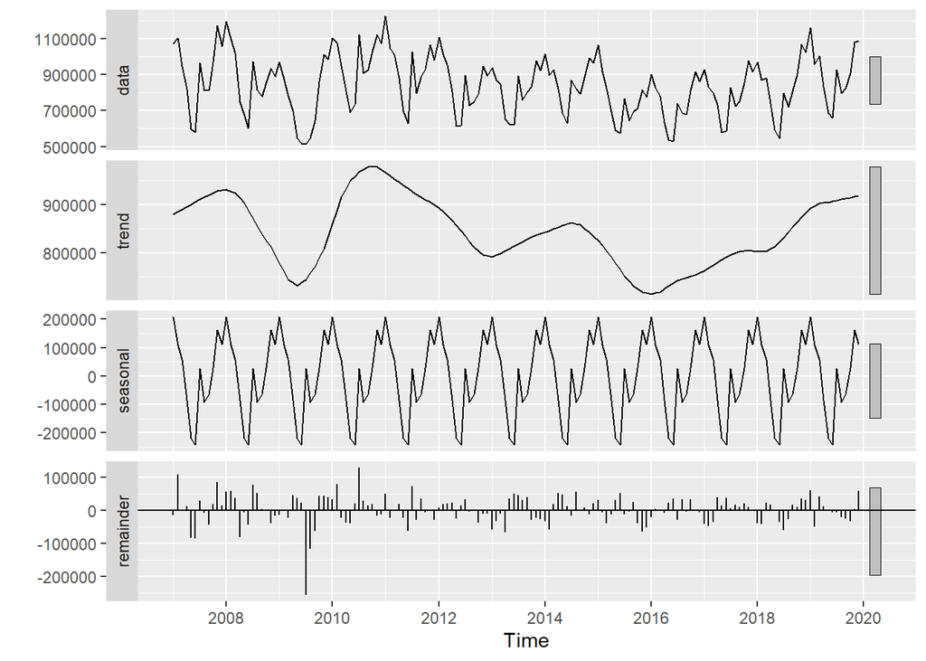

```r
autoplot(stl(SdT1sinout, s.window = "periodic"), ts.colour="blue" )
```

Se puede comprobar que no hay eventos o intervenciones relevantes, se mantiene una estacionalidad y una tendencia variable.

### Analisis exploratorio de la base

```r
gt(psych::describe(SdT1sinout))
```

| vars | n | mean | sd | median | trimmed | mad | min | max | range | skew | kurtosis | se |
| --- | --- | --- | --- | --- | --- | --- | --- | --- | --- | --- | --- | --- |
| 1 | 156 | 843496.7 | 163645.9 | 838108 | 844112.1 | 174844.5 | 514856 | 1223545 | 708689 | -0.03604553 | -0.718023 | 13102.16 |

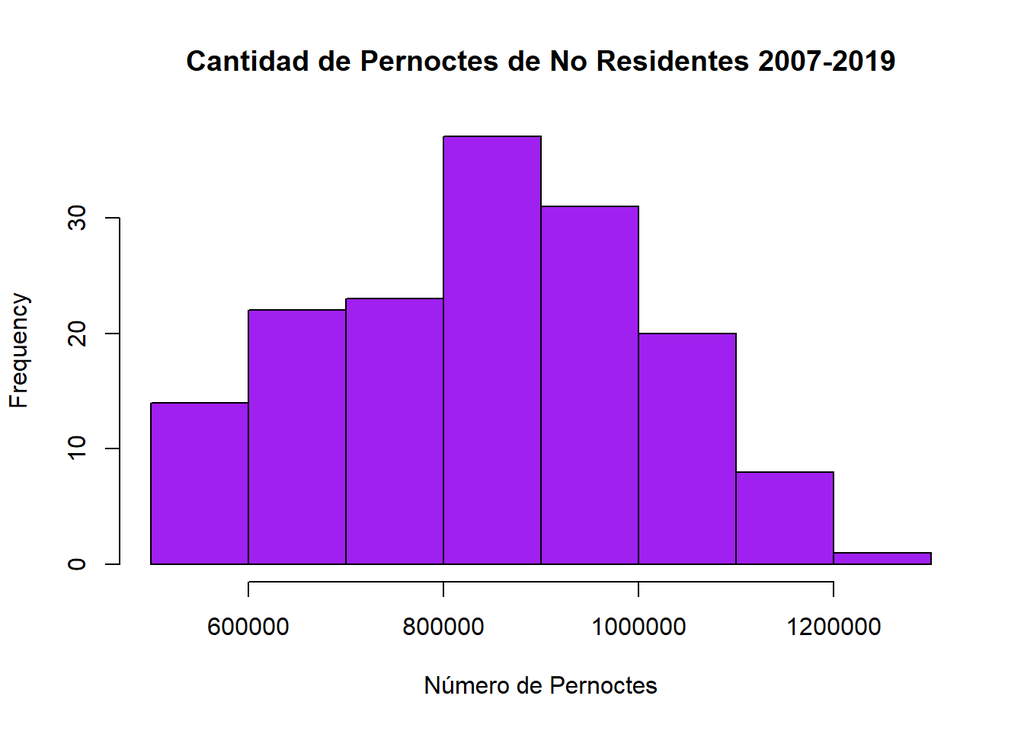

```r
hist(SdT1sinout, col = "purple", main = "Cantidad de Pernoctes de No Residentes 2007-2019",
     xlab = "Número de Pernoctes")
```

En una primera aproximación se obtiene que la distribución de la serie se aproxima a la distribución normal a grandes razgos. De los datos se extrae que la media es levemente superior a la mediana. Lo cual se corrobora con los quantiles.

*Supuestos de normalidad:*

Se corrobora con Jarque-Bera, Anderson-Darling y Shapiro-Wilk:

```r
jarque.bera.test(data11$pernoctes_no_residentes)
```

```
##
##  Jarque Bera Test
##
## data:  data11$pernoctes_no_residentes
## X-squared = 3.1155, df = 2, p-value = 0.2106
```

```r
ad.test(data11$pernoctes_no_residentes)
```

```
##
##  Anderson-Darling normality test
##
## data:  data11$pernoctes_no_residentes
## A = 0.4279, p-value = 0.3081
```

```r
shapiro.test(data11$pernoctes_no_residentes)
```

```
##
##  Shapiro-Wilk normality test
##
## data:  data11$pernoctes_no_residentes
## W = 0.98604, p-value = 0.1193
```

El p-value del test es mayor a una significancia de 0.05 en todos los casos, por lo que se indica NO RECHAZAR la H0 de normalidad.

### Analisis de la estacionariedad

Se grafican la serie, FAS, FAC y FACP para una primera interpretación de la estacionaridad:

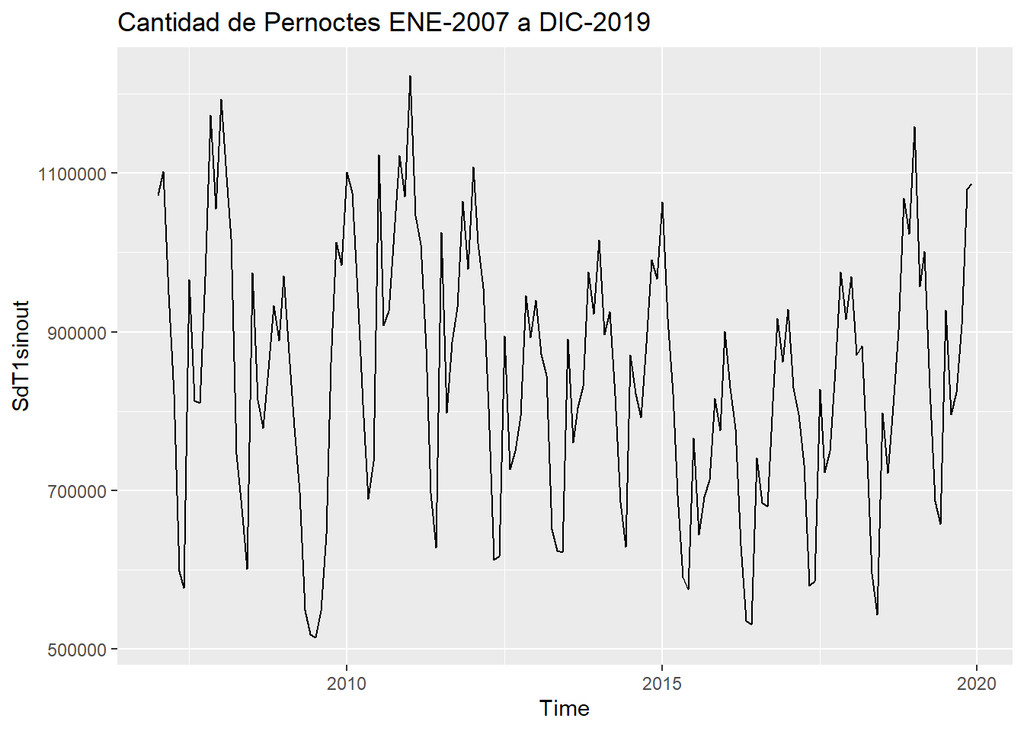

```r
autoplot(SdT1sinout, main="Cantidad de Pernoctes ENE-2007 a DIC-2019")
```

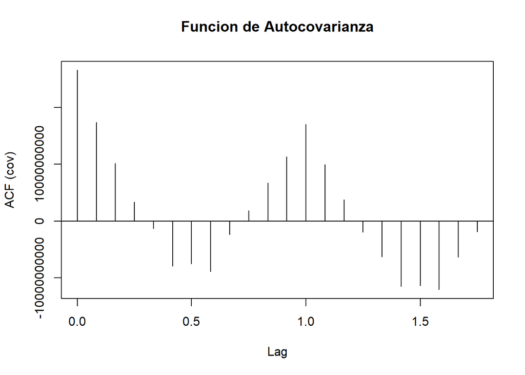

```r
acf(SdT1sinout, type = "cov",  main="Funcion de Autocovarianza")
```

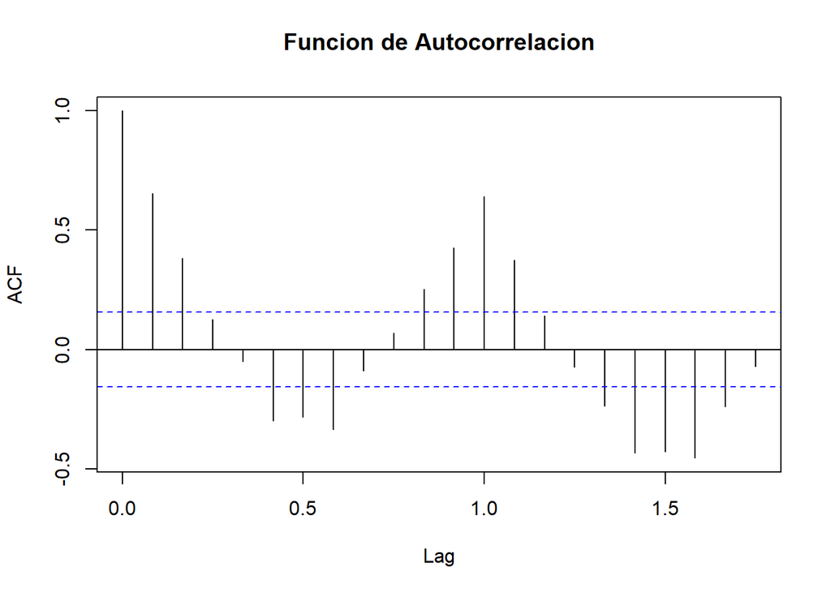

```r
#par(mfrow=c(2,1))
g1<-acf(SdT1sinout, main="Funcion de Autocorrelacion")
```

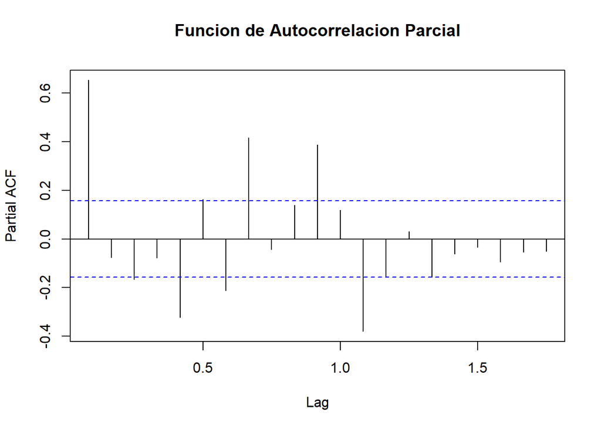

```r
g2<-pacf(SdT1sinout, main="Funcion de Autocorrelacion Parcial")
```

#### Estacionaridad en la varianza

Se verifica la estacionaridad en la varianza y ver la necesidad de aplicar una transformación, a través del lambda propuesto por la función “powerTransform”:

```r
summary(powerTransform(data11$pernoctes_no_residentes))
```

```
## bcPower Transformation to Normality
##                                Est Power Rounded Pwr Wald Lwr Bnd Wald Upr Bnd
## data11$pernoctes_no_residentes    0.9707           1       0.2139       1.7276
##
## Likelihood ratio test that transformation parameter is equal to 0
##  (log transformation)
##                            LRT df     pval
## LR test, lambda = (0) 6.409315  1 0.011352
##
## Likelihood ratio test that no transformation is needed
##                              LRT df    pval
## LR test, lambda = (1) 0.00574365  1 0.93959
```

El resultado es un Est power = 0.97 (lambda estimado), se define que no es necesaria una transformación. El test verifica que el p-value es muy chico cuando se testea lambda=0 (se rechaza la H0: lambda=0 o sea, log-transform) y grande para lambda=1 (no se rechaza la H0: lambda=1, no es necesaria una transformación).

Finalmente se toma como referencia el resultado de Jarque-Bera de normalidad y no se transforma la serie original.

#### Estacionaridad en la media

Se testea la periodicidad presente en la serie:

```r
frequency(SdT1sinout)
```

```
## [1] 12
```

1. LJUNG - BOX

A partir del test de Ljung-Box, el rechazo de H0 significa que hay coeficientes de autocorrelación distintos a cero, y hay variabilidad en la Variancia.

```r
Incorrelation <- function(ts, type = c("Ljung-Box","Box-Pierce"), fitdf = 0){
  p_ljung_box = NULL
  s_ljung_box = NULL
  for(i in 0:(length(ts)/4)){
    p_ljung_box[i] = Box.test(ts,lag = i,type = type,fitdf = fitdf)$p.value
    s_ljung_box[i] = Box.test(ts,lag = i,type = type,fitdf = fitdf)$statistic
  }
  table = data.frame(j = 1:(length(ts)/4),
                     P_Value = p_ljung_box,
                     Statistic = s_ljung_box)
  return(table)
}

Incorrelation(SdT1sinout,"Ljung-Box")
```

```
##     j                  P_Value Statistic
## 1   1 0.0000000000000002220446  67.90127
## 2   2 0.0000000000000000000000  91.41004
## 3   3 0.0000000000000000000000  93.92481
## 4   4 0.0000000000000000000000  94.32319
## 5   5 0.0000000000000000000000 108.96247
## 6   6 0.0000000000000000000000 122.26324
## 7   7 0.0000000000000000000000 140.79615
## 8   8 0.0000000000000000000000 142.14729
## 9   9 0.0000000000000000000000 142.91745
## 10 10 0.0000000000000000000000 153.67048
## 11 11 0.0000000000000000000000 184.68175
## 12 12 0.0000000000000000000000 254.75958
## 13 13 0.0000000000000000000000 278.83994
## 14 14 0.0000000000000000000000 282.35511
```

[output cut: 25 more lines]

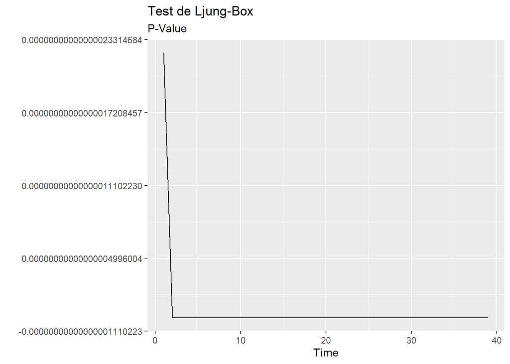

```r
inco_wn = Incorrelation(SdT1sinout,"Ljung-Box")
autoplot(ts(inco_wn$P_Value)) + ggtitle("Test de Ljung-Box", subtitle = "P-Value") + ylab("") # Grafico los p-value para distintos lags
```

Todos los p-values dan muy bajos, por lo que SE RECHAZA la H0, y se interpreta que la serie tiene coeficientes de autocorrelaci?n distintos a cero.

Tests de Raíces Unitarias para determinar estacionaridad: se prueban varios test para verificar consistencia en las respuestas.

2. DICKEY-FULLER
- H0: RAIZ UNITARIA (NO ESTACIONARIO)
- H1: NO HAY RAIZ UNITARIA (ESTACIONARIO)

```r
df<-tseries::adf.test(SdT1sinout)
df
```

```
##
##  Augmented Dickey-Fuller Test
##
## data:  SdT1sinout
## Dickey-Fuller = -5.2349, Lag order = 5, p-value = 0.01
## alternative hypothesis: stationary
```

El test de AUG D-F resulta en un p-value bajo, por lo que se rechaza la H0 y la serie de tiempo sería ESTACIONARIA. Dado que este test tiene un sesgo a rechazar la H0, se aplicarán otros test de hipótesis.

3. Se aplican las pruebas Dickey-Fuller Aumentado con sus tres posibilidades (paquete URCA)

3.1) TIPO 0 - NONE

```r
urca_none<-urca::ur.df(SdT1sinout, selectlags = "AIC", type = "none")
urca_none
```

```
##
## ###############################################################
## # Augmented Dickey-Fuller Test Unit Root / Cointegration Test #
## ###############################################################
##
## The value of the test statistic is: -0.8739
```

```r
summary(urca_none)
```

```
##
## ###############################################
## # Augmented Dickey-Fuller Test Unit Root Test #
## ###############################################
##
## Test regression none
##
##
## Call:
## lm(formula = z.diff ~ z.lag.1 - 1 + z.diff.lag)
##
## Residuals:
##     Min      1Q  Median      3Q     Max
## -269319  -88884  -17595   98521  399985
##
## Coefficients:
##            Estimate Std. Error t value Pr(>|t|)
## z.lag.1    -0.01103    0.01262  -0.874    0.384
## z.diff.lag -0.11092    0.08060  -1.376    0.171
##
## Residual standard error: 133600 on 152 degrees of freedom
## Multiple R-squared:  0.0185, Adjusted R-squared:  0.005586
## F-statistic: 1.433 on 2 and 152 DF,  p-value: 0.2419
##
##
## Value of test-statistic is: -0.8739
##
## Critical values for test statistics:
##       1pct  5pct 10pct
## tau1 -2.58 -1.95 -1.62
```

Si se toma un nivel de significancia de 0.05, el tau estadistico es mayor al valor crítico y por lo tanto NO se RECHAZA la H0. La serie no es estacionaria cuando no se considera tendencia y/o drift.

3.2) TIPO 1 - DRIFT

```r
urca_drift<-urca::ur.df(SdT1sinout, selectlags = "AIC", type = "drift")
urca_drift
```

```
##
## ###############################################################
## # Augmented Dickey-Fuller Test Unit Root / Cointegration Test #
## ###############################################################
##
## The value of the test statistic is: -5.4517 14.8607
```

```r
summary(urca_drift)
```

```
##
## ###############################################
## # Augmented Dickey-Fuller Test Unit Root Test #
## ###############################################
##
## Test regression drift
##
##
## Call:
## lm(formula = z.diff ~ z.lag.1 + 1 + z.diff.lag)
##
## Residuals:
##     Min      1Q  Median      3Q     Max
## -221847  -94625  -13948   82672  345509
##
## Coefficients:
##                 Estimate   Std. Error t value    Pr(>|t|)
## (Intercept) 307649.58021  57309.37085   5.368 0.000000294 ***
## z.lag.1         -0.36618      0.06717  -5.452 0.000000199 ***
## z.diff.lag       0.06688      0.08116   0.824       0.411
## ---
## Signif. codes:  0 '***' 0.001 '**' 0.01 '*' 0.05 '.' 0.1 ' ' 1
##
## Residual standard error: 122800 on 151 degrees of freedom
## Multiple R-squared:  0.1758, Adjusted R-squared:  0.1649
## F-statistic:  16.1 on 2 and 151 DF,  p-value: 0.0000004577
##
##
## Value of test-statistic is: -5.4517 14.8607
##
## Critical values for test statistics:
##       1pct  5pct 10pct
## tau2 -3.46 -2.88 -2.57
## phi1  6.52  4.63  3.81
```

Si se toma un nivel de significancia de 0.05, el tau estadistico es menor al valor crítico y por lo tanto se RECHAZA la H0. Por otro lado el phi1-estadistico es mayor al phi1 crítico (H0: existe raíz unitaria sin drift), lo cual lleva a rechazar ésta H0. La serie es estacionaria con drift.

3.3) TIPO 2 - TREND & DRIFT

```r
urca_trend <- urca::ur.df(SdT1sinout, selectlags = "AIC", type = "trend")
urca_trend
```

```
##
## ###############################################################
## # Augmented Dickey-Fuller Test Unit Root / Cointegration Test #
## ###############################################################
##
## The value of the test statistic is: -5.4065 9.8794 14.8191
```

```r
summary(urca_trend)
```

```
##
## ###############################################
## # Augmented Dickey-Fuller Test Unit Root Test #
## ###############################################
##
## Test regression trend
##
##
## Call:
## lm(formula = z.diff ~ z.lag.1 + 1 + tt + z.diff.lag)
##
## Residuals:
##     Min      1Q  Median      3Q     Max
## -226783  -97797  -14228   86275  342446
##
## Coefficients:
##                 Estimate   Std. Error t value    Pr(>|t|)
## (Intercept) 316216.20695  63843.99617   4.953 0.000001948 ***
## z.lag.1         -0.36984      0.06841  -5.407 0.000000248 ***
## tt             -69.97678    226.94570  -0.308       0.758
## z.diff.lag       0.06963      0.08190   0.850       0.397
## ---
## Signif. codes:  0 '***' 0.001 '**' 0.01 '*' 0.05 '.' 0.1 ' ' 1
##
## Residual standard error: 123200 on 150 degrees of freedom
## Multiple R-squared:  0.1763, Adjusted R-squared:  0.1598
## F-statistic:  10.7 on 3 and 150 DF,  p-value: 0.000002042
##
##
## Value of test-statistic is: -5.4065 9.8794 14.8191
##
## Critical values for test statistics:
##       1pct  5pct 10pct
## tau3 -3.99 -3.43 -3.13
## phi2  6.22  4.75  4.07
## phi3  8.43  6.49  5.47
```

Si se toma un nivel de significancia de 0.05, el tau estadistico es menor al valor crítico y por lo tanto se RECHAZA la H0. Al continuar el análisis, el estadístico para phi2 es mayor que el valor crítico, por lo tanto se rechaza la H0: existe raíz unitaria, sin drift y sin tendencia. El estadístico para phi3 es mayor que el valor crítico, por lo que se rechaza la H0: existe raíz unitaria y sin tendencia. Notar que el sentido de rechazo - no rechazo de la H0 es inverso entre tau y los phi.

La serie es estacionaria con tendencia y drift (pendiente e intercepto).

4. Se compara ahora con un ndiffs con argumentos iguales a este test:

```r
ndiffs(SdT1sinout, alpha = 0.05, test = "adf")
```

```
## [1] 0
```

```r
ndiffs(SdT1sinout, alpha = 0.05, test = "kpss")
```

```
## [1] 0
```

```r
ndiffs(SdT1sinout, alpha = 0.05, test = "pp")
```

```
## [1] 0
```

Estos resultados de test indican que la serie no precisa diferenciar para un nivel de significancia de 0.05.

```r
kpss.test(SdT1sinout)
```

```
##
##  KPSS Test for Level Stationarity
##
## data:  SdT1sinout
## KPSS Level = 0.21968, Truncation lag parameter = 4, p-value = 0.1
```

6. Se prueba con test de Phillips-Perron. Hipotesis nula que existe al menos una Raíz Unitaria

```r
pp.test(SdT1sinout)
```

```
##
##  Phillips-Perron Unit Root Test
##
## data:  SdT1sinout
## Dickey-Fuller Z(alpha) = -59.757, Truncation lag parameter = 4, p-value
## = 0.01
## alternative hypothesis: stationary
```

El resultado indica que debe rechazarce la H0, y por lo tanto la serie es estacionaria.

### Cambios estructurales

Ahora se investigan los cambios estructurales mediante el Test de Zivot-Andrews.

```r
SdTsinout.za <- ur.za(SdT1sinout, model="both")
summary(SdTsinout.za)
```

```
##
## ################################
## # Zivot-Andrews Unit Root Test #
## ################################
##
##
## Call:
## lm(formula = testmat)
##
## Residuals:
##     Min      1Q  Median      3Q     Max
## -238389  -96079   -6878   88210  337664
##
## Coefficients:
##                 Estimate   Std. Error t value             Pr(>|t|)
## (Intercept) 328228.43935  61529.51321   5.334          0.000000347 ***
## y.l1             0.61840      0.06337   9.759 < 0.0000000000000002 ***
## trend           40.08721    441.37585   0.091               0.9278
## du          -86978.87926  41875.39687  -2.077               0.0395 *
## dt            2040.60672   1078.66842   1.892               0.0604 .
## ---
## Signif. codes:  0 '***' 0.001 '**' 0.01 '*' 0.05 '.' 0.1 ' ' 1
##
## Residual standard error: 121600 on 150 degrees of freedom
##   (1 observation deleted due to missingness)
## Multiple R-squared:  0.4589, Adjusted R-squared:  0.4444
## F-statistic:  31.8 on 4 and 150 DF,  p-value: < 0.00000000000000022
##
##
## Teststatistic: -6.0221
## Critical values: 0.01= -5.57 0.05= -5.08 0.1= -4.82
##
## Potential break point at position: 98
```

El estadístico de test de la serie es menor al valor crítico (inclusive para alpha = 0.01), por lo que SE RECHAZA LA H0 de existencia de una raíz unitaria por cambio estructural. Esto indica que la serie es estacionaria con cambio estructural. Se plantea un quiebre en el mes 98. Se verifica la existencia de cambios estructurales en la serie.

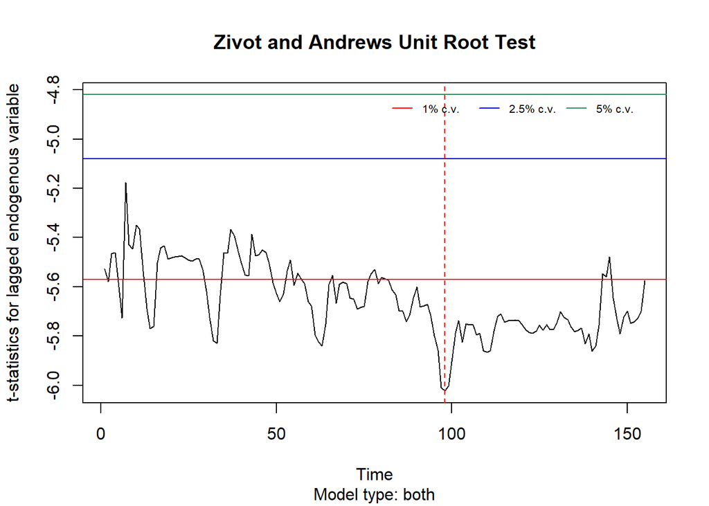

```r
plot(SdTsinout.za)
```

#### Cambios estructurales con tendencia ( SdT1sinout ~ timeline1 )

A partir del hallazgo de estacionariedad con tendencia en test anterior, se busca determinar los cambios estructurales y las rectas de regresión lineal asociadas con el siguiente modelado:

```r
len <- length(SdT1sinout)
timeline1 <- 1:len
trend_fit <- lm(SdT1sinout ~ timeline1)
summary(trend_fit)
```

```
##
## Call:
## lm(formula = SdT1sinout ~ timeline1)
##
## Residuals:
##     Min      1Q  Median      3Q     Max
## -351980 -118122    5821  104650  365554
##
## Coefficients:
##             Estimate Std. Error t value            Pr(>|t|)
## (Intercept) 882067.4    26172.0  33.703 <0.0000000000000002 ***
## timeline1     -491.3      289.2  -1.699              0.0913 .
## ---
## Signif. codes:  0 '***' 0.001 '**' 0.01 '*' 0.05 '.' 0.1 ' ' 1
##
## Residual standard error: 162700 on 154 degrees of freedom
## Multiple R-squared:  0.0184, Adjusted R-squared:  0.01203
## F-statistic: 2.887 on 1 and 154 DF,  p-value: 0.09134
```

El p-value del intercepto indica que es significativo (RECHAZA H0), mientras que el p-value de la pendiente no sería significativo (NO SE RECHAZA LA H0), siendo entonces este coeficiente despreciable en la ecuación. Por ello se considera el cambio estructural de nivel.

#### Cambio estructural de nivel/drift ( SdT1sinout ~ 1 )

Se prueban otras ventanas de tiempo, cuyo resultado siempre devuelve coeficientes significativos.

```r
SdT1sinout ~ 1
```

```
## SdT1sinout ~ 1
```

```r
summary(lm(SdT1sinout ~ 1))
```

```
##
## Call:
## lm(formula = SdT1sinout ~ 1)
##
## Residuals:
##     Min      1Q  Median      3Q     Max
## -328641 -118128   -5389  122383  380048
##
## Coefficients:
##             Estimate Std. Error t value            Pr(>|t|)
## (Intercept)   843497      13102   64.38 <0.0000000000000002 ***
## ---
## Signif. codes:  0 '***' 0.001 '**' 0.01 '*' 0.05 '.' 0.1 ' ' 1
##
## Residual standard error: 163600 on 155 degrees of freedom
```

```r
coeftest(lm(SdT1sinout ~ 1))
```

```
##
## t test of coefficients:
##
##             Estimate Std. Error t value              Pr(>|t|)
## (Intercept)   843497      13102  64.378 < 0.00000000000000022 ***
## ---
## Signif. codes:  0 '***' 0.001 '**' 0.01 '*' 0.05 '.' 0.1 ' ' 1
```

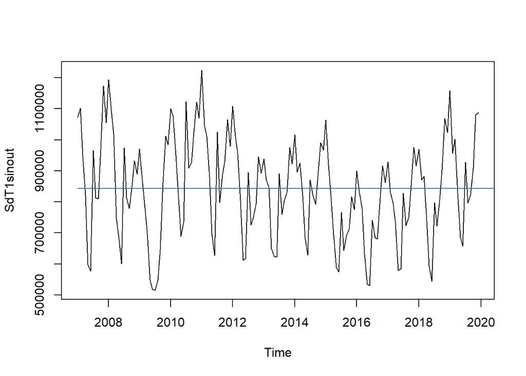

```r
plot(SdT1sinout)
lines(ts(fitted(lm(SdT1sinout ~ 1)), start=2007 ,frequency = 1), col = 4)
```

Se buscan los breakpoints del cambio estructural:

```r
SdT1brk <- breakpoints(SdT1sinout ~ 1, h = 0.1)
summary(SdT1brk)
```

```
##
##   Optimal (m+1)-segment partition:
##
## Call:
## breakpoints.formula(formula = SdT1sinout ~ 1, h = 0.1)
##
## Breakpoints at observation number:
##
## m = 1            63
## m = 2                  99         141
## m = 3   15 33    63
## m = 4   15 33    63               141
## m = 5   15 33    63    99         141
## m = 6   15 33    63    99 117     141
## m = 7   15 33    63 82 99 117     141
## m = 8   15 34 49 64 81 99 117     141
## m = 9   15 34 49 64 81 96 111 126 141
##
## Corresponding to breakdates:
##
## m = 1                            2012(3)
## m = 2                                             2015(3)
## m = 3   2008(3) 2009(9)          2012(3)
## m = 4   2008(3) 2009(9)          2012(3)
## m = 5   2008(3) 2009(9)          2012(3)          2015(3)
## m = 6   2008(3) 2009(9)          2012(3)          2015(3)  2016(9)
## m = 7   2008(3) 2009(9)          2012(3) 2013(10) 2015(3)  2016(9)
## m = 8   2008(3) 2009(10) 2011(1) 2012(4) 2013(9)  2015(3)  2016(9)
## m = 9   2008(3) 2009(10) 2011(1) 2012(4) 2013(9)  2014(12) 2016(3) 2017(6)
##
## m = 1
## m = 2   2018(9)
## m = 3
## m = 4   2018(9)
## m = 5   2018(9)
## m = 6   2018(9)
## m = 7   2018(9)
## m = 8   2018(9)
## m = 9   2018(9)
##
## Fit:
##
## m   0             1             2             3             4
## RSS 4150898525535 3899223881664 3626903837317 3332419784583 3087895120945
## BIC          4198          4198          4197          4194          4192
##
## m   5             6             7             8             9
## RSS 2970682544154 2880396221548 2791633929060 2789489996076 2918423435774
## BIC          4196          4201          4206          4216          4233
```

A partir de los resultados de encontrar m = 1 a 9 puntos de ruptura con las fechas asociadas y las métricas {RSS, BIC}, el valor mínimo de BIC ocurre en m = 4. Trazamos la salida de la función breakpoint() para obtener una comprensión visual:

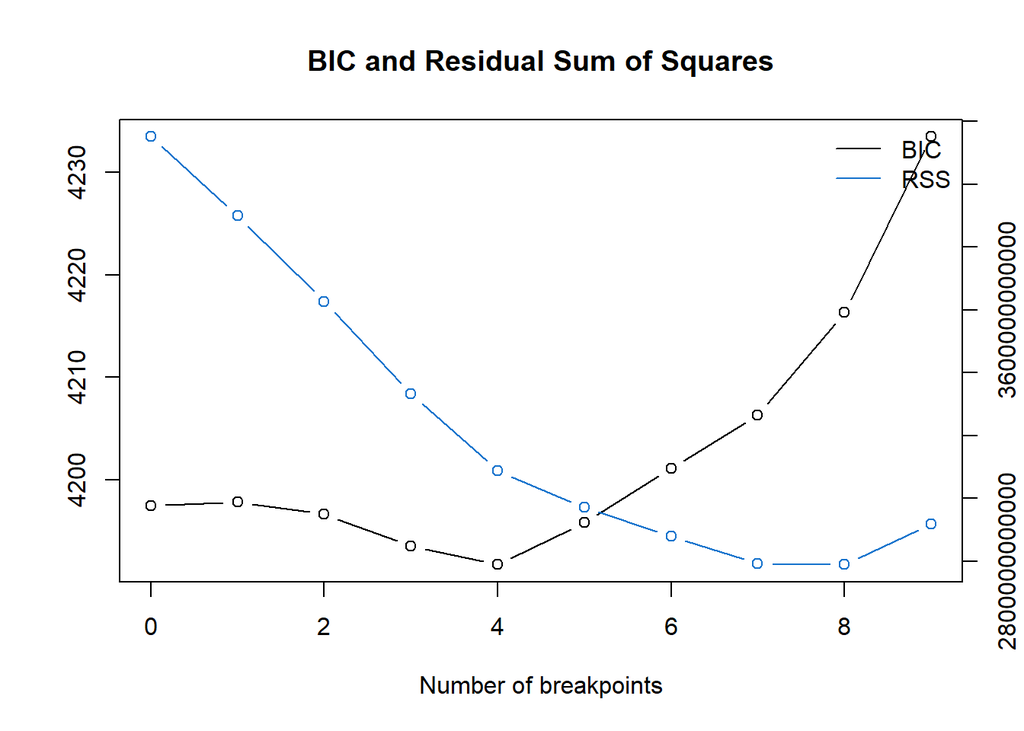

```r
plot(SdT1brk)
```

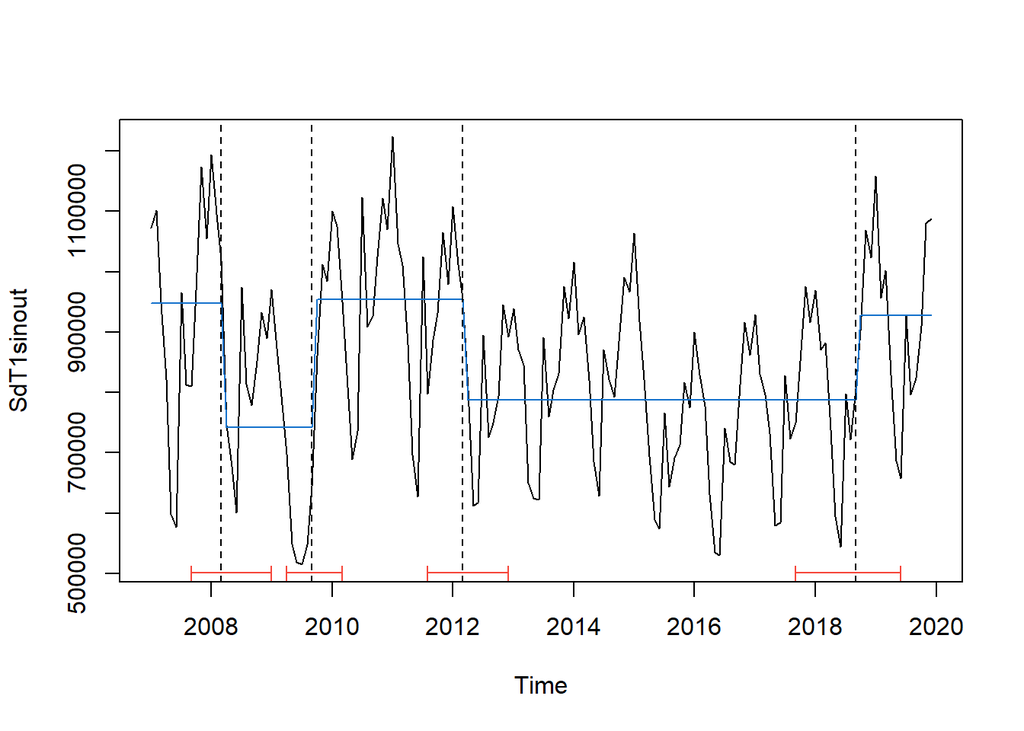

```r
plot(SdT1sinout)
lines(fitted(SdT1brk, breaks = 4), col = 4)
lines(confint(SdT1brk, breaks = 4))
```

Se elige optar por un solo punto de quiebre para trabajar con mayor cantidad de datos. Los valores BIC para los primeros 4 breakpoints no son muy diferentes.

**Serie con 1 break**

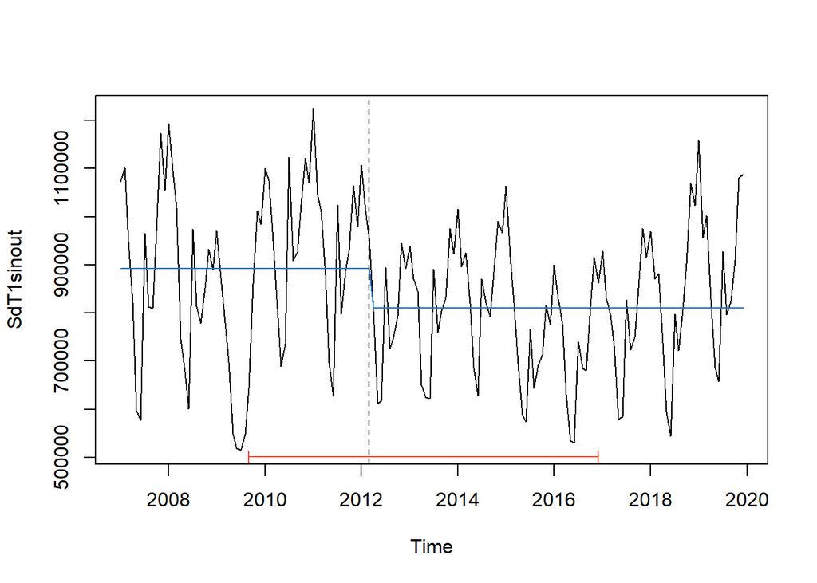

```r
plot(SdT1sinout)
lines(fitted(SdT1brk, breaks = 1), col = 4)
lines(confint(SdT1brk, breaks = 1))
```

Las fechas de quiebre:

```r
breakdates(SdT1brk, breaks = 1)
```

```
## [1] 2012.167
```

Los coeficientes:

```r
coef(SdT1brk, breaks = 1)
```

```
##                    (Intercept)
## 2007(1) - 2012(3)     892297.7
## 2012(4) - 2019(12)    810438.0
```

Se generará el modelo de la serie temporal con el intervalo a partir de 04.2012, según el punto de quiebre encontrado.

### Modelos

Se definen los subconjuntos de train y test para la serie final correspondiente al intervalo definido (04.2012 - 12.2019):

```r
serieFinal <- window(SdT1sinout,
                    start = c(2012,04),
                    end = c(2019,12))
serieejTrain <-  window(SdT1sinout,
                    start = c(2012,03),
                    end = c(2018,12))
serieejTest <-  window(SdT1sinout,
                    start = c(2019,01),
                    end = c(2019,12))
```

Se utiliza la función auto.arima para comprobar los modelos sugeridos por el algoritmo en el intervalo de serie acotado:

```r
auto.arima(serieFinal)
```

```
## Series: serieFinal
## ARIMA(0,1,1)(0,1,1)[12]
##
## Coefficients:
##           ma1     sma1
##       -0.2965  -0.8435
## s.e.   0.1177   0.2534
##
## sigma^2 estimated as 1544712221:  log likelihood=-965.86
## AIC=1937.72   AICc=1938.04   BIC=1944.87
```

**Modelo 1 ajustado solo con datos Train**

Modelo ARIMA(0,1,1)(0,1,1)[12]:

```r
model_1break <- Arima(serieejTrain,
                 order = c(0,1,1),
                 seasonal = list(order = c(0,1,1), period=12),
                 include.mean = TRUE)

summary(model_1break)
```

```
## Series: serieejTrain
## ARIMA(0,1,1)(0,1,1)[12]
##
## Coefficients:
##           ma1     sma1
##       -0.2220  -0.8827
## s.e.   0.1348   0.3988
##
## sigma^2 estimated as 1443133513:  log likelihood=-832.34
## AIC=1670.68   AICc=1671.05   BIC=1677.39
##
## Training set error measures:
##                    ME     RMSE      MAE       MPE     MAPE      MASE
## Training set 5132.335 34338.69 24107.09 0.6115581 3.120256 0.3791619
##                      ACF1
## Training set -0.005373753
```

Se generan los gráficos de serie original, valores ajustados en período Train y predicción en período Test:

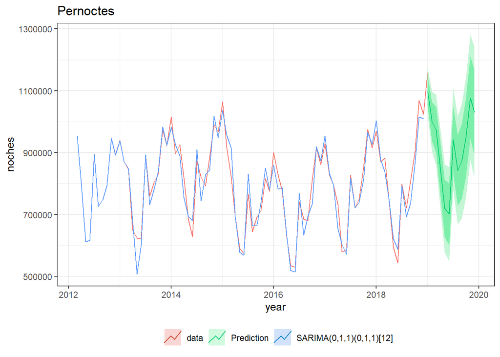

```r
fit22 <- forecast(model_1break, h=12)

autoplot (serieFinal, series="data") +
  autolayer(model_1break$fitted,series="SARIMA(0,1,1)(0,1,1)[12]")+
  autolayer(fit22 , series="Prediction")+
  xlab("year") + ylab("noches")+ ggtitle("Pernoctes")+ theme_bw()+ theme (legend.title = element_blank(),legend.position = "bottom")
```

Se generan los criterios de información del modelo para Train y Test:

```r
accuracy(fit22 , serieejTest)
```

```
##                      ME     RMSE      MAE        MPE     MAPE      MASE
## Training set   5132.335 34338.69 24107.09  0.6115581 3.120256 0.3791619
## Test set     -11224.144 39602.58 35655.60 -1.8119730 4.039798 0.5607993
##                      ACF1 Theil's U
## Training set -0.005373753        NA
## Test set      0.022963250 0.2454371
```

### Analisis de residuos del modelo

Se analizan los residuos del modelo 1 (Train):

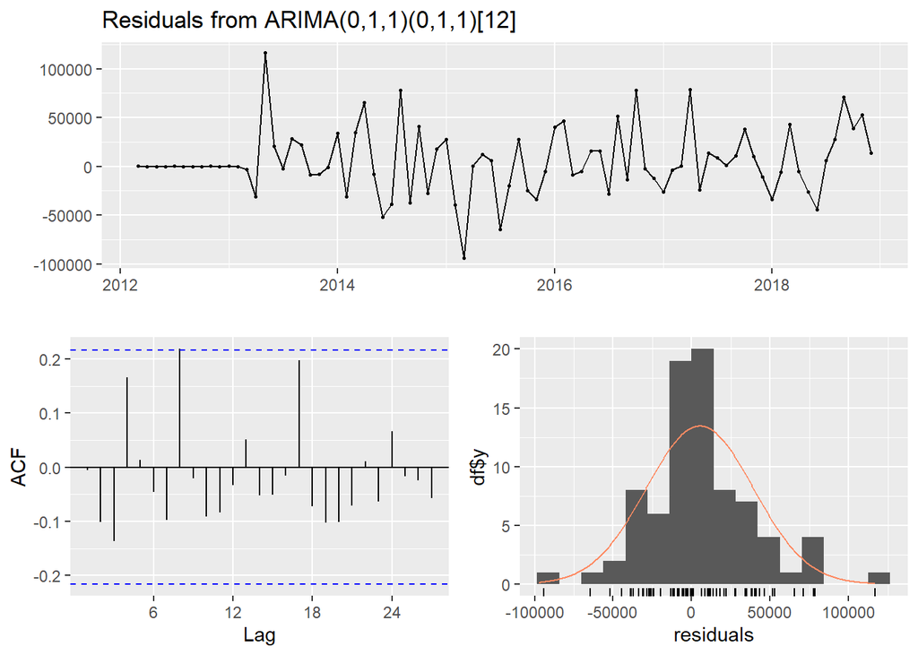

```
##
##  Ljung-Box test
##
## data:  Residuals from ARIMA(0,1,1)(0,1,1)[12]
## Q* = 12.908, df = 14, p-value = 0.5337
##
## Model df: 2.   Total lags used: 16
```

```r
checkresiduals(model_1break)
```

```r
LjungBoxTest(residuals(model_1break), k = 2, lag.max = 20)
```

```
##   m    Qm     pvalue
##   1  0.00 0.96047752
##   2  0.88 0.34836037
##   3  2.50 0.11406927
##   4  4.93 0.08498476
##   5  4.95 0.17568240
##   6  5.14 0.27345182
##   7  6.02 0.30473572
##   8 10.47 0.10617800
##   9 10.51 0.16143785
##  10 11.30 0.18544472
##  11 11.97 0.21474825
##  12 12.08 0.27959701
##  13 12.34 0.33850277
##  14 12.61 0.39781357
##  15 12.88 0.45691080
##  16 12.91 0.53374938
##  17 17.04 0.31632339
##  18 17.61 0.34751062
##  19 18.75 0.34325596
##  20 19.89 0.33913938
```

Resultan p-values mayores que nivel de significancia 0.05 (el menor encontrado es 0.084), por lo que NO se rechaza la H0 de Ljung-Box test (H0: Los residuos están distribuidos independientemente). El gráfico de PAC solo muestra apenas significativo un lag (8), pero se lo considera incluido por el error del intervalo de confianza.

### Predicciónes

```r
model_p <- Arima(serieFinal,
                 order = c(0,1,1),
                 seasonal = list(order = c(0,1,1), period=12),
                 include.mean = TRUE)

summary(model_p)
```

```
## Series: serieFinal
## ARIMA(0,1,1)(0,1,1)[12]
##
## Coefficients:
##           ma1     sma1
##       -0.2965  -0.8435
## s.e.   0.1177   0.2534
##
## sigma^2 estimated as 1544712221:  log likelihood=-965.86
## AIC=1937.72   AICc=1938.04   BIC=1944.87
##
## Training set error measures:
##                   ME     RMSE     MAE       MPE     MAPE      MASE       ACF1
## Training set 5286.91 35993.96 26172.5 0.5532082 3.271872 0.3973479 0.03764361
```

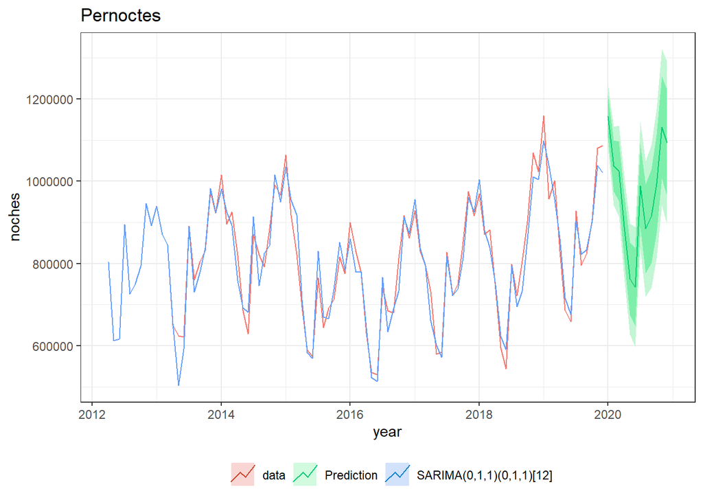

```r
fit2 <- forecast(model_p, h=12)

autoplot (serieFinal, series="data") +
  autolayer(model_p$fitted,series="SARIMA(0,1,1)(0,1,1)[12]")+
  autolayer(fit2 , series="Prediction")+
  xlab("year") + ylab("noches")+ ggtitle("Pernoctes")+ theme_bw()+ theme (legend.title = element_blank(),legend.position = "bottom")
```

## Serie de tiempo 2:

Se importa el dataset y se configura como serie de tiempo:

### Analisis exploratorio de la base

```r
psych::describe(data2)
```

```
##       vars  n mean   sd median trimmed  mad min  max range skew kurtosis   se
## fecha    1 58  NaN   NA     NA     NaN   NA Inf -Inf  -Inf   NA       NA   NA
## IPC      2 58 2.94 1.17    2.8    2.85 1.26 1.2  6.6   5.4 0.69     0.45 0.15
```

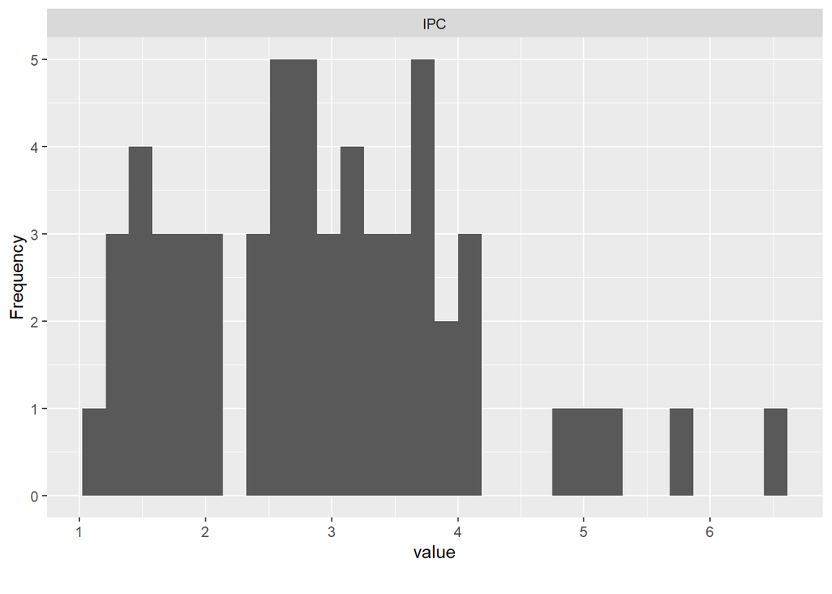

```r
plot_histogram(data2)
```

```r
SdT2 <-  ts(data2$`IPC`,
            frequency = 12,
            start = c(2017,1))

data.class(SdT2)
```

```
## [1] "ts"
```

Se realizan una breve visualización de los datos:

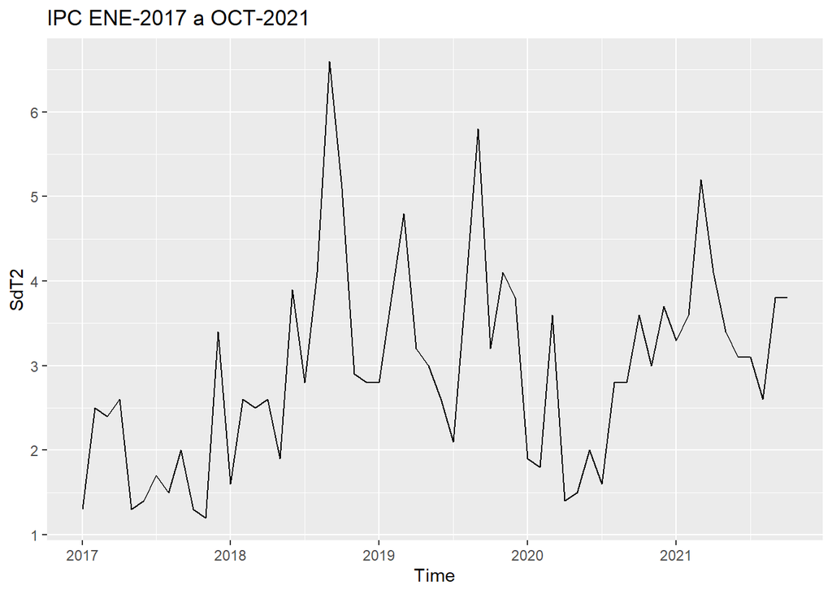

```r
autoplot(SdT2, main="IPC ENE-2017 a OCT-2021")
```

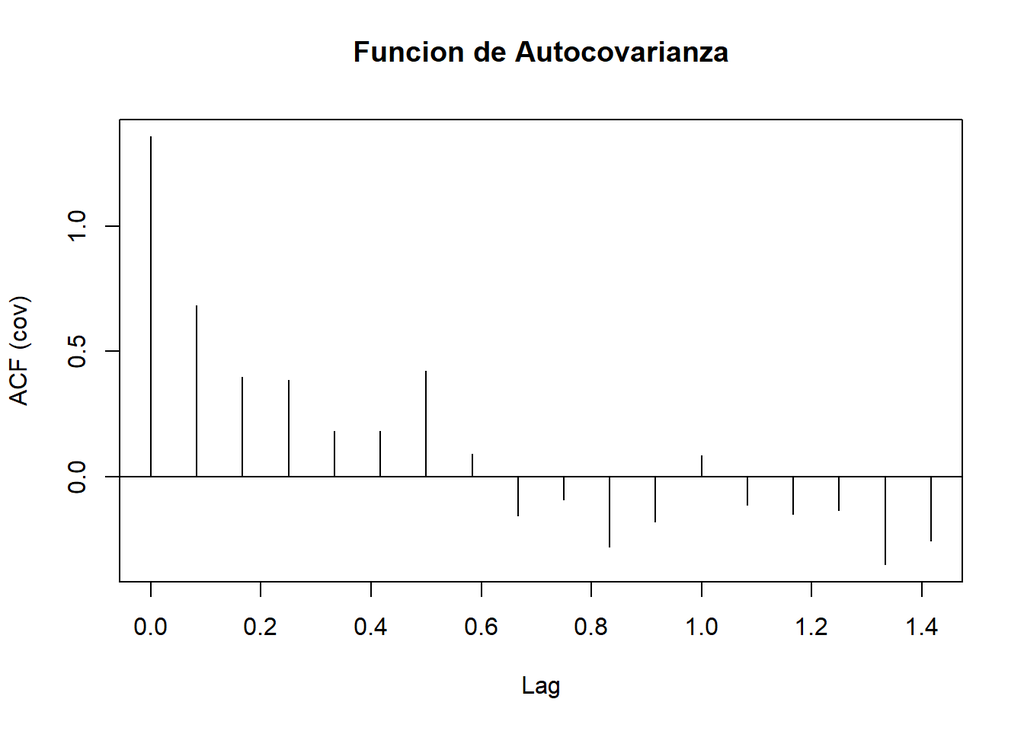

```r
acf(SdT2, type = "cov",  main="Funcion de Autocovarianza")
```

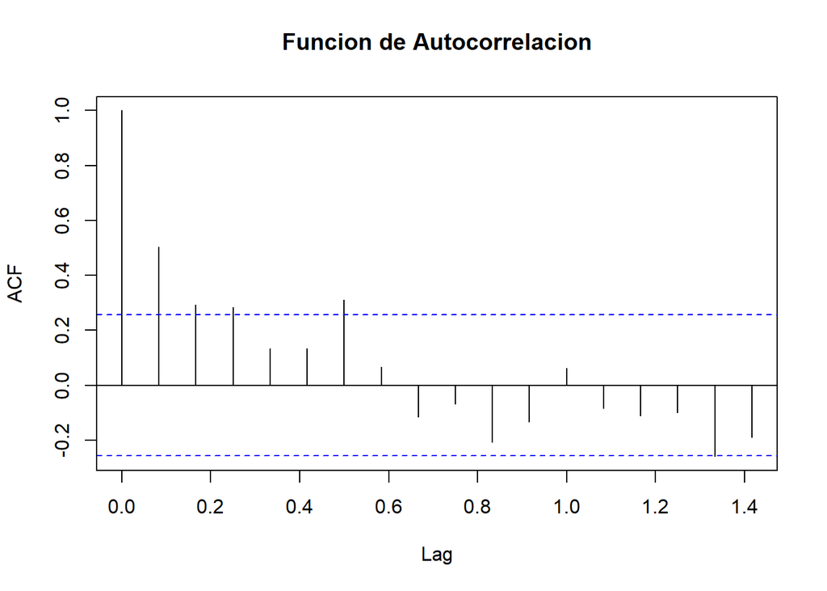

```r
#par(mfrow=c(2,1))
g1<-acf(SdT2, main="Funcion de Autocorrelacion")
```

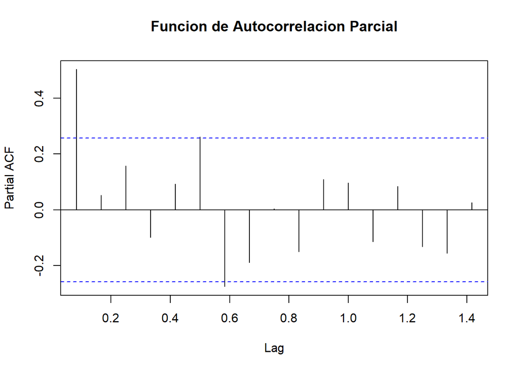

```r
g2<-pacf(SdT2, main="Funcion de Autocorrelacion Parcial")
```

Se agrega una visualización de los componentes de la serie de tiempo a partir de la ecuación básica (YT = Ct + St + Tt + Et)

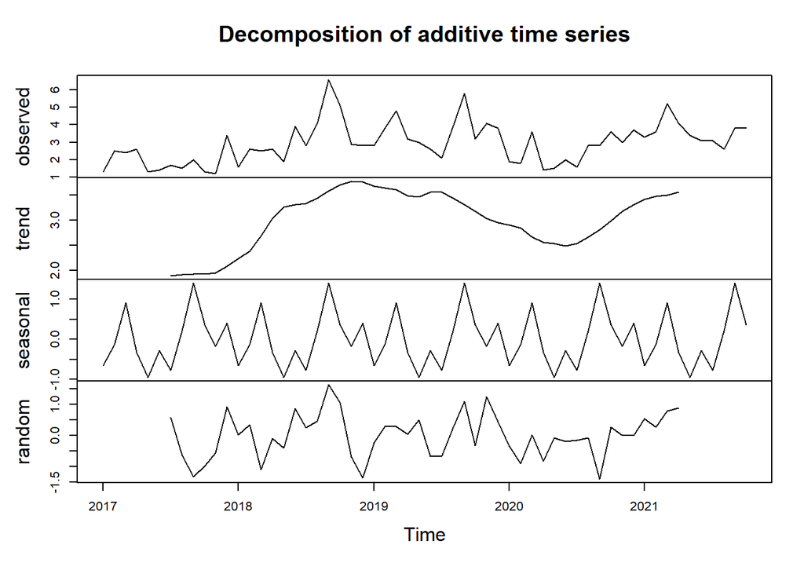

```r
plot(decompose(SdT2))
```

A priori, se observan períodos con variabilidad cambiante y cambios estructurales en la tendencia. También se observan tendencias variantes a lo largo de la serie. Los coeficientes de autocorrelación decrecen rapidamente en el grafico de FAC (ACF).

Se comprueba el supuesto de normalidad de la serie original data2:

```r
jarque.bera.test(data2$IPC)
```

```
##
##  Jarque Bera Test
##
## data:  data2$IPC
## X-squared = 5.6337, df = 2, p-value = 0.05979
```

```r
ad.test(data2$IPC)
```

```
##
##  Anderson-Darling normality test
##
## data:  data2$IPC
## A = 0.5945, p-value = 0.1177
```

```r
shapiro.test(data2$IPC)
```

```
##
##  Shapiro-Wilk normality test
##
## data:  data2$IPC
## W = 0.95023, p-value = 0.01864
```

El valor de p-value es mayor al alpha = 0.05, por lo que NO SE RECHAZA la H0 de normalidad de la serie data2 para Jarque-Bera y Anderson-Darling. Sin embargo, el test Shapiro-Wilk indica que se debe RECHAZAR la H0 de normalidad, por lo tanto se analiza la variancia de la serie antes de avanzar con el modelo.

### Analisis de la estacionariedad

#### Estacionariedad en la varianza

Al rechazar normalidad, se define la transformación de potencia adecuada:

```r
summary(powerTransform(SdT2))
```

```
## bcPower Transformation to Normality
##      Est Power Rounded Pwr Wald Lwr Bnd Wald Upr Bnd
## SdT2    0.2611           0      -0.3253       0.8474
##
## Likelihood ratio test that transformation parameter is equal to 0
##  (log transformation)
##                           LRT df    pval
## LR test, lambda = (0) 0.75258  1 0.38566
##
## Likelihood ratio test that no transformation is needed
##                            LRT df   pval
## LR test, lambda = (1) 6.224424  1 0.0126
```

```r
lambda = powerTransform(SdT2)

data2$IPC_t <- data2$IPC ^ lambda$lambda
```

Se comprueba el supuesto de normalidad de la serie original data2 transformada:

```r
jarque.bera.test(data2$IPC_t)
```

```
##
##  Jarque Bera Test
##
## data:  data2$IPC_t
## X-squared = 0.6572, df = 2, p-value = 0.7199
```

```r
ad.test(data2$IPC_t)
```

```
##
##  Anderson-Darling normality test
##
## data:  data2$IPC_t
## A = 0.52526, p-value = 0.1735
```

```r
shapiro.test(data2$IPC_t)
```

```
##
##  Shapiro-Wilk normality test
##
## data:  data2$IPC_t
## W = 0.97291, p-value = 0.2195
```

En este caso, la H0 de normalidad se confirma (NO SE RECHAZA) en todos los test de normalidad.

Se construye ahora la serie de tiempo a partir de la variable transformada:

```r
SdT2_t <- ts(data2$`IPC_t`,
            frequency = 12,
            start = c(2017,1))
```

Se verifica si la serie tiene perioricidad:

```r
frequency(SdT2_t)
```

```
## [1] 12
```

La prueba arroja una frecuencia/estacionalidad de 12 (meses)

#### Estacionariedad en la media

1. LJUNG - BOX

Si se rechaza H0 significa que hay coeficientes de autocorrelación distintos a cero, y hay variabilidad en la Variancia.

```r
Incorrelation <- function(ts, type = c("Ljung-Box","Box-Pierce"), fitdf = 0){
  p_ljung_box = NULL
  s_ljung_box = NULL
  for(i in 0:(length(ts)/4)){
    p_ljung_box[i] = Box.test(ts,lag = i,type = type,fitdf = fitdf)$p.value
    s_ljung_box[i] = Box.test(ts,lag = i,type = type,fitdf = fitdf)$statistic
  }
  table = data.frame(j = 1:(length(ts)/4),
                     P_Value = p_ljung_box,
                     Statistic = s_ljung_box)
  return(table)
}

Incorrelation(SdT2_t,"Ljung-Box") # Ver funci?n autocorrelaci?n al incio del script
```

```
##     j          P_Value Statistic
## 1   1 0.00006199607605  16.04068
## 2   2 0.00000407686082  24.82037
## 3   3 0.00000028152210  33.27699
## 4   4 0.00000024037147  36.39154
## 5   5 0.00000028368175  38.61632
## 6   6 0.00000005422786  44.67802
## 7   7 0.00000012919723  45.12726
## 8   8 0.00000027242860  45.68831
## 9   9 0.00000064315463  45.84606
## 10 10 0.00000062655051  47.97757
## 11 11 0.00000057570033  50.20204
## 12 12 0.00000127970962  50.21690
## 13 13 0.00000182284668  51.24171
## 14 14 0.00000217141604  52.66216
```

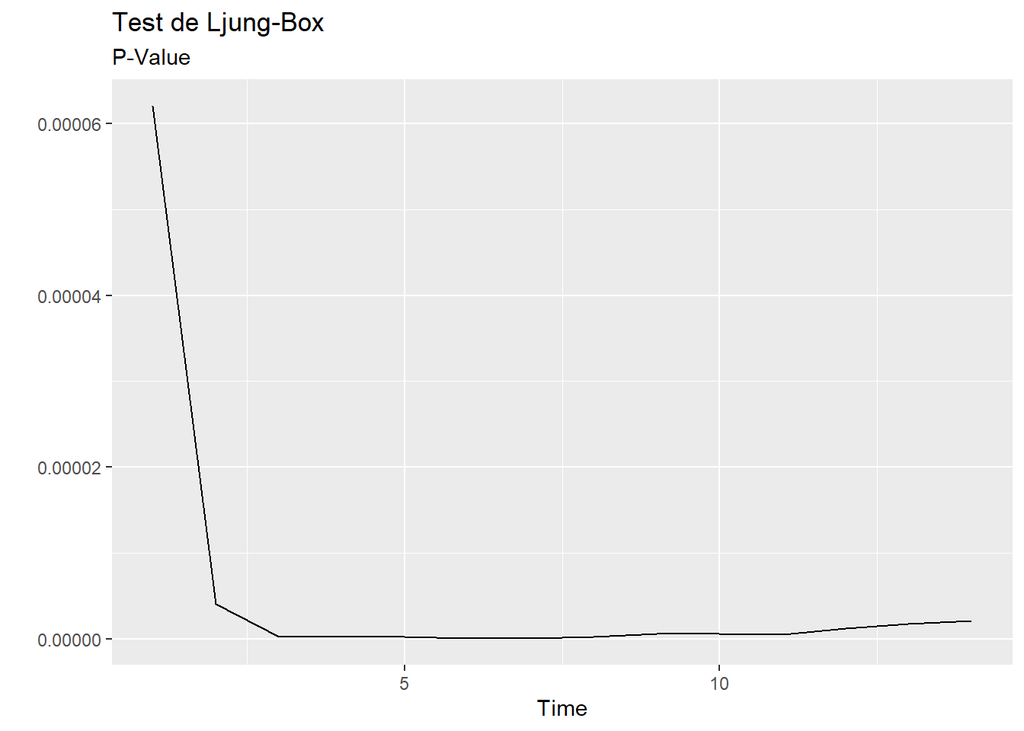

```r
inco_wn = Incorrelation(SdT2_t,"Ljung-Box")
autoplot(ts(inco_wn$P_Value)) + ggtitle("Test de Ljung-Box", subtitle = "P-Value") + ylab("") # Grafico los p-value para disntitos lags
```

Todos los p-values dan muy bajos, por lo que SE RECHAZA la H0, y la serie tiene coeficientes de autocorrelación distintos a cero.

Tests de Raíces Unitarias para determinar estacionaridad.

2. DICKEY-FULLER

H0: RAIZ UNITARIA ( NO ESTACIONARIO ) H1: NO HAY RAIZ UNITARIA ( ESTACIONARIO )

```r
df<-tseries::adf.test(SdT2_t)
df
```

```
##
##  Augmented Dickey-Fuller Test
##
## data:  SdT2_t
## Dickey-Fuller = -2.6799, Lag order = 3, p-value = 0.3002
## alternative hypothesis: stationary
```

El test de AUG D-F resulta en un p-value alto, por lo que no se rechaza la H0 y la serie de tiempo sería NO ESTACIONARIA.

3. Dickey-Fuller Aumentado

3.1) TIPO 0 - NONE

```r
urca_none<-urca::ur.df(SdT2_t, selectlags = "AIC", type = "none")
urca_none
```

```
##
## ###############################################################
## # Augmented Dickey-Fuller Test Unit Root / Cointegration Test #
## ###############################################################
##
## The value of the test statistic is: 0.0241
```

```r
summary(urca_none)
```

```
##
## ###############################################
## # Augmented Dickey-Fuller Test Unit Root Test #
## ###############################################
##
## Test regression none
##
##
## Call:
## lm(formula = z.diff ~ z.lag.1 - 1 + z.diff.lag)
##
## Residuals:
##      Min       1Q   Median       3Q      Max
## -0.24610 -0.07640 -0.00798  0.07750  0.31985
##
## Coefficients:
##              Estimate Std. Error t value Pr(>|t|)
## z.lag.1     0.0003083  0.0128086   0.024  0.98088
## z.diff.lag -0.3376420  0.1257749  -2.684  0.00963 **
## ---
## Signif. codes:  0 '***' 0.001 '**' 0.01 '*' 0.05 '.' 0.1 ' ' 1
##
## Residual standard error: 0.1255 on 54 degrees of freedom
## Multiple R-squared:  0.1185, Adjusted R-squared:  0.08586
## F-statistic:  3.63 on 2 and 54 DF,  p-value: 0.03318
##
##
## Value of test-statistic is: 0.0241
##
## Critical values for test statistics:
##      1pct  5pct 10pct
## tau1 -2.6 -1.95 -1.61
```

Si se toma un nivel de significancia de 0.05, el tau estadistico es mayor al valor crítico y por lo tanto NO se RECHAZA la H0. La serie no es estacionaria cuando no consideramos tendencia y drift.

3.2) TIPO 1 - DRIFT

```r
urca_drift<-urca::ur.df(SdT2_t, selectlags = "AIC", type = "drift")
urca_drift
```

```
##
## ###############################################################
## # Augmented Dickey-Fuller Test Unit Root / Cointegration Test #
## ###############################################################
##
## The value of the test statistic is: -2.9995 4.5438
```

```r
summary(urca_drift)
```

```
##
## ###############################################
## # Augmented Dickey-Fuller Test Unit Root Test #
## ###############################################
##
## Test regression drift
##
##
## Call:
## lm(formula = z.diff ~ z.lag.1 + 1 + z.diff.lag)
##
## Residuals:
##       Min        1Q    Median        3Q       Max
## -0.238856 -0.091167 -0.002356  0.071055  0.262354
##
## Coefficients:
##             Estimate Std. Error t value Pr(>|t|)
## (Intercept)   0.5162     0.1712   3.014  0.00394 **
## z.lag.1      -0.3920     0.1307  -2.999  0.00411 **
## z.diff.lag   -0.1512     0.1326  -1.140  0.25931
## ---
## Signif. codes:  0 '***' 0.001 '**' 0.01 '*' 0.05 '.' 0.1 ' ' 1
##
## Residual standard error: 0.117 on 53 degrees of freedom
## Multiple R-squared:  0.2472, Adjusted R-squared:  0.2188
## F-statistic: 8.703 on 2 and 53 DF,  p-value: 0.0005391
##
##
## Value of test-statistic is: -2.9995 4.5438
##
## Critical values for test statistics:
##       1pct  5pct 10pct
## tau2 -3.51 -2.89 -2.58
## phi1  6.70  4.71  3.86
```

Si se toma un nivel de significancia de 0.05, el tau estadistico es menor al valor crítico y por lo tanto se RECHAZA la H0. La serie es estacionaria con drift. El valor del phi1-estadístico es menor al phi1 crítico para significancia de 0.05 (H0: existe raíz unitaria sin drift), lo cual lleva a no rechazar ésta H0. Esto no coincide con el resultado de tau.

3.3) TIPO 2 - TREND & DRIFT

```r
urca_trend<-urca::ur.df(SdT2_t, selectlags = "AIC", type = "trend")
urca_trend
```

```
##
## ###############################################################
## # Augmented Dickey-Fuller Test Unit Root / Cointegration Test #
## ###############################################################
##
## The value of the test statistic is: -3.358 3.7907 5.6397
```

```r
summary(urca_trend)
```

```
##
## ###############################################
## # Augmented Dickey-Fuller Test Unit Root Test #
## ###############################################
##
## Test regression trend
##
##
## Call:
## lm(formula = z.diff ~ z.lag.1 + 1 + tt + z.diff.lag)
##
## Residuals:
##       Min        1Q    Median        3Q       Max
## -0.256097 -0.081667 -0.009033  0.062689  0.282588
##
## Coefficients:
##              Estimate Std. Error t value Pr(>|t|)
## (Intercept)  0.583035   0.175673   3.319  0.00166 **
## z.lag.1     -0.477729   0.142264  -3.358  0.00147 **
## tt           0.001525   0.001053   1.448  0.15364
## z.diff.lag  -0.104963   0.135083  -0.777  0.44067
## ---
## Signif. codes:  0 '***' 0.001 '**' 0.01 '*' 0.05 '.' 0.1 ' ' 1
##
## Residual standard error: 0.1158 on 52 degrees of freedom
## Multiple R-squared:  0.2764, Adjusted R-squared:  0.2346
## F-statistic: 6.621 on 3 and 52 DF,  p-value: 0.0007139
##
##
## Value of test-statistic is: -3.358 3.7907 5.6397
##
## Critical values for test statistics:
##       1pct  5pct 10pct
## tau3 -4.04 -3.45 -3.15
## phi2  6.50  4.88  4.16
## phi3  8.73  6.49  5.47
```

Si se toma un nivel de significancia de 0.05, el tau estadistico es mayor al valor crítico y por lo tanto NO se RECHAZA la H0. La serie NO es estacionaria con tendencia y drift (pendiente e intercepto). Los valores de phi2 y phi3 indican que NO SE RECHAZA las respectivas H0 para cada caso, en mismo nivel de significancia. Los resultados de estos tres tests indican que la serie es estacionaria con drift.

4. ndiffs con argumentos iguales a este test:

```r
ndiffs(SdT2_t, alpha = 0.05, test = "adf")
```

```
## [1] 0
```

```r
ndiffs(SdT2_t, alpha = 0.05, test = "kpss")
```

```
## [1] 1
```

```r
ndiffs(SdT2_t, alpha = 0.05, test = "pp")
```

```
## [1] 0
```

Con una significancia de 0.05, para los test de Augm Dickey-Fuller y Philips-Perron la serie no precisa diferenciar. Por otro lado, con test “kpss” el resultado indica que la serie debe ser diferenciada una vez.

```r
kpss.test(SdT2_t)
```

```
##
##  KPSS Test for Level Stationarity
##
## data:  SdT2_t
## KPSS Level = 0.45051, Truncation lag parameter = 3, p-value = 0.05538
```

6. Se prueba con test de Phillips-Perron. Hipotesis nula que existe al menos una Raíz Unitaria:

```r
pp.test(SdT2_t)
```

```
##
##  Phillips-Perron Unit Root Test
##
## data:  SdT2_t
## Dickey-Fuller Z(alpha) = -33.655, Truncation lag parameter = 3, p-value
## = 0.01
## alternative hypothesis: stationary
```

El p-value resulta en RECHAZO de la H0, e indica que la serie no necesita ser diferenciada. Esto coincide con el resultado de ndiffs para P-P.

7. Test de Zivot-Andrews - Como se interpreta de la grafica que puede haber cambios estructurales en la serie, realizamos el test ur.za.

```r
SdT2_t.za <- ur.za(SdT2_t, model="both")
summary(SdT2_t.za)
```

```
##
## ################################
## # Zivot-Andrews Unit Root Test #
## ################################
##
##
## Call:
## lm(formula = testmat)
##
## Residuals:
##      Min       1Q   Median       3Q      Max
## -0.16973 -0.06678 -0.01585  0.06369  0.28261
##
## Coefficients:
##              Estimate Std. Error t value    Pr(>|t|)
## (Intercept)  0.875011   0.149503   5.853 0.000000329 ***
## y.l1         0.234676   0.129377   1.814     0.07546 .
## trend        0.006657   0.002165   3.075     0.00335 **
## du          -0.220289   0.067234  -3.276     0.00188 **
## dt           0.003168   0.004013   0.789     0.43345
## ---
## Signif. codes:  0 '***' 0.001 '**' 0.01 '*' 0.05 '.' 0.1 ' ' 1
##
## Residual standard error: 0.1069 on 52 degrees of freedom
##   (1 observation deleted due to missingness)
## Multiple R-squared:  0.4304, Adjusted R-squared:  0.3866
## F-statistic: 9.824 on 4 and 52 DF,  p-value: 0.000005376
##
##
## Teststatistic: -5.9155
## Critical values: 0.01= -5.57 0.05= -5.08 0.1= -4.82
##
## Potential break point at position: 36
```

El estadístico de test de la serie es menor al valor crítico (inclusive para alpha = 0.01), por lo que SE RECHAZA LA H0 de existencia de una raíz unitaria por cambio estructural. Esto indica que la serie es estacionaria con cambio estructural.

Se plantea un quiebre en el mes 36, equivalente con dic-2019.

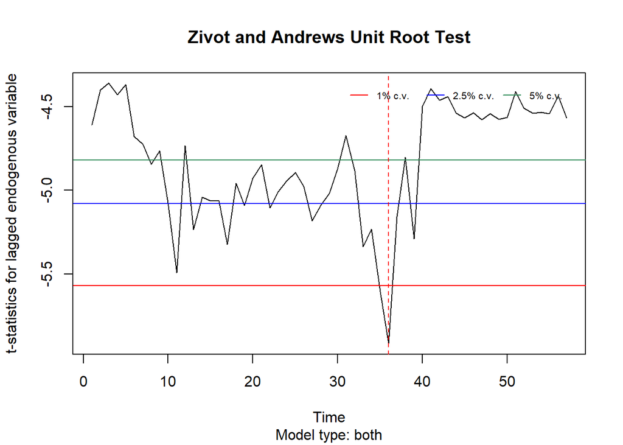

```r
plot(SdT2_t.za)
```

Se debe asumir que el test de Zivot-Andrews arroja resultados más confiables con grandes tamaños muestrales. En este caso, no se trataría de una muestra de este tipo.

### Cambios estructurales

##### Cambio estructural por tendencia ( SdT2_t ~ timeline )

Se busca determinar los cambios estructurales y las rectas de regresión lineal asociadas con el siguiente modelado:

```r
len <- length(SdT2_t)
timeline <- 1:len
trend_fit <- lm(SdT2_t ~ timeline)
summary(trend_fit)
```

```
##
## Call:
## lm(formula = SdT2_t ~ timeline)
##
## Residuals:
##      Min       1Q   Median       3Q      Max
## -0.24817 -0.09339  0.01940  0.05899  0.35890
##
## Coefficients:
##             Estimate Std. Error t value             Pr(>|t|)
## (Intercept) 1.208884   0.034183  35.365 < 0.0000000000000002 ***
## timeline    0.003278   0.001008   3.252              0.00194 **
## ---
## Signif. codes:  0 '***' 0.001 '**' 0.01 '*' 0.05 '.' 0.1 ' ' 1
##
## Residual standard error: 0.1285 on 56 degrees of freedom
## Multiple R-squared:  0.1589, Adjusted R-squared:  0.1438
## F-statistic: 10.58 on 1 and 56 DF,  p-value: 0.001942
```

Los p-values de intercepto y tendencia son muy pequeños, por lo que RECHAZAMOS la H0 que los considera no significativos.

Se identifican los posible puntos de quiebre de la tendencia:

```r
SdT2_tbrk <- breakpoints(SdT2_t ~ timeline, h = 0.1)
summary(SdT2_tbrk)
```

```
##
##   Optimal (m+1)-segment partition:
##
## Call:
## breakpoints.formula(formula = SdT2_t ~ timeline, h = 0.1)
##
## Breakpoints at observation number:
##
## m = 1                     36
## m = 2         17          36
## m = 3         19       31    43
## m = 4      11 19       31    43
## m = 5      11    20 25 31    43
## m = 6      11    20 25 31 39       52
## m = 7      11    20 25 31 36 43    52
## m = 8      11 17 22 27 32 38 43    52
## m = 9    5 11 17 22 27 32 38 43    52
## m = 10   5 11 17 22 27 32 38 43 48 53
##
## Corresponding to breakdates:
##
## m = 1                                                      2019(12)
## m = 2                     2018(5)                          2019(12)
## m = 3                     2018(7)                  2019(7)          2020(7)
## m = 4            2017(11) 2018(7)                  2019(7)          2020(7)
## m = 5            2017(11)         2018(8)  2019(1) 2019(7)          2020(7)
## m = 6            2017(11)         2018(8)  2019(1) 2019(7) 2020(3)
## m = 7            2017(11)         2018(8)  2019(1) 2019(7) 2019(12) 2020(7)
## m = 8            2017(11) 2018(5) 2018(10) 2019(3) 2019(8) 2020(2)  2020(7)
## m = 9    2017(5) 2017(11) 2018(5) 2018(10) 2019(3) 2019(8) 2020(2)  2020(7)
## m = 10   2017(5) 2017(11) 2018(5) 2018(10) 2019(3) 2019(8) 2020(2)  2020(7)
##
## m = 1
## m = 2
## m = 3
## m = 4
## m = 5
## m = 6             2021(4)
## m = 7             2021(4)
## m = 8             2021(4)
## m = 9             2021(4)
## m = 10   2020(12) 2021(5)
##
## Fit:
##
## m   0        1        2        3        4        5        6        7
## RSS   0.9245   0.6367   0.5379   0.4434   0.3823   0.3244   0.2920   0.2707
## BIC -63.2813 -72.7283 -70.3335 -69.3517 -65.7730 -63.1085 -57.0357 -49.2450
##
## m   8        9        10
## RSS   0.2624   0.2602   0.2650
## BIC -38.8722 -27.1914 -13.9429
```

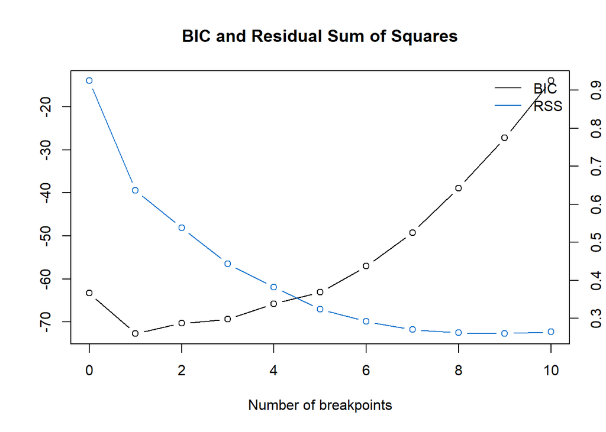

```r
plot(SdT2_tbrk)
```

El mejor Criterio de información se da para m=1

Se visualiza el punto de corte:

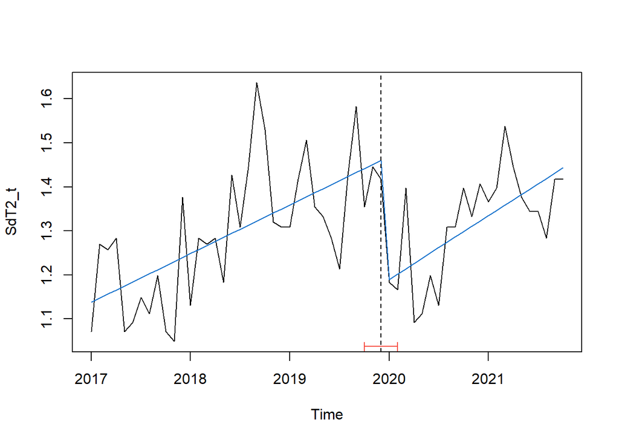

```r
plot(SdT2_t)
lines(fitted(SdT2_tbrk, breaks = 1), col = 4)
lines(confint(SdT2_tbrk, breaks = 1))
```

Fecha de corte:

```r
breakdates(SdT2_tbrk, breaks = 1)
```

```
## [1] 2019.917
```

Coeficientes de corte:

```r
coef(SdT2_tbrk, breaks = 1)
```

```
##                    (Intercept)    timeline
## 2017(1) - 2019(12)   1.1287154 0.009206744
## 2020(1) - 2021(10)   0.7429107 0.012070437
```

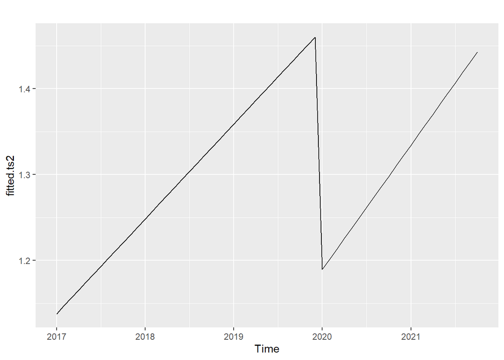

```r
fitted.ts2 <- fitted(SdT2_tbrk, breaks = 1)
autoplot(fitted.ts2)
```

### Modelos

Se dividen los datos de train and test (80-20):

```r
SdT2_ttrain <- window(SdT2_t,
                    start = c(2017,01),
                    end = c(2020,10))

SdT2_ttest <- window(SdT2_t,
                    start = c(2020,11),
                    end = c(2021,10))
```

Se genera el modelo según mejor performance:

```r
auto.arima(SdT2_t, trace = T, stepwise = T)
```

```
##
##  ARIMA(2,1,2)(1,0,1)[12] with drift         : Inf
##  ARIMA(0,1,0)            with drift         : -64.36635
##  ARIMA(1,1,0)(1,0,0)[12] with drift         : -72.73736
##  ARIMA(0,1,1)(0,0,1)[12] with drift         : -75.29782
##  ARIMA(0,1,0)                               : -66.39643
##  ARIMA(0,1,1)            with drift         : -74.53761
##  ARIMA(0,1,1)(1,0,1)[12] with drift         : Inf
##  ARIMA(0,1,1)(1,0,0)[12] with drift         : -76.39347
##  ARIMA(0,1,0)(1,0,0)[12] with drift         : -67.66944
##  ARIMA(1,1,1)(1,0,0)[12] with drift         : Inf
##  ARIMA(0,1,2)(1,0,0)[12] with drift         : -74.56111
##  ARIMA(1,1,2)(1,0,0)[12] with drift         : Inf
##  ARIMA(0,1,1)(1,0,0)[12]                    : -78.51389
##  ARIMA(0,1,1)                               : -76.4054
##  ARIMA(0,1,1)(1,0,1)[12]                    : Inf
##  ARIMA(0,1,1)(0,0,1)[12]                    : -77.37406
##  ARIMA(0,1,0)(1,0,0)[12]                    : -69.83745
##  ARIMA(1,1,1)(1,0,0)[12]                    : -76.70712
##  ARIMA(0,1,2)(1,0,0)[12]                    : -76.67258
##  ARIMA(1,1,0)(1,0,0)[12]                    : -74.95235
##  ARIMA(1,1,2)(1,0,0)[12]                    : -75.93263
##
##  Best model: ARIMA(0,1,1)(1,0,0)[12]
```

```
## Series: SdT2_t
## ARIMA(0,1,1)(1,0,0)[12]
##
## Coefficients:
##           ma1    sar1
##       -0.5078  0.2898
## s.e.   0.1318  0.1331
##
## sigma^2 estimated as 0.01335:  log likelihood=42.48
## AIC=-78.97   AICc=-78.51   BIC=-72.84
```

A partir de la mejor sugerencia, se estima el modelo SARIMA: ARIMA(0,1,1)(1,0,0)[12]:

```r
model2_1 <- Arima(SdT2_ttrain,
                 order = c(0,1,1),
                 seasonal = list(order = c(1,0,0), period=12),
                 include.mean = TRUE)

summary(model2_1)
```

```
## Series: SdT2_ttrain
## ARIMA(0,1,1)(1,0,0)[12]
##
## Coefficients:
##           ma1    sar1
##       -0.5606  0.3213
## s.e.   0.1540  0.1608
##
## sigma^2 estimated as 0.0155:  log likelihood=30.08
## AIC=-54.16   AICc=-53.58   BIC=-48.74
##
## Training set error measures:
##                       ME      RMSE        MAE        MPE     MAPE     MASE
## Training set 0.006302009 0.1203768 0.09796848 -0.1306514 7.560753 0.625702
##                    ACF1
## Training set 0.08382275
```

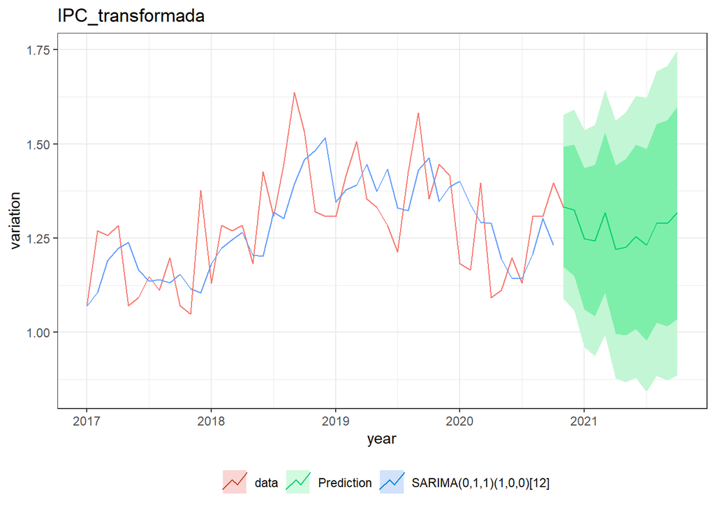

```r
fit21 <- forecast(model2_1, h=12)

autoplot (SdT2_t, series="data") +
  autolayer(model2_1$fitted,series="SARIMA(0,1,1)(1,0,0)[12]")+
  autolayer(fit21 , series="Prediction")+
  xlab("year") + ylab("variation")+ ggtitle("IPC_transformada")+ theme_bw()+ theme (legend.title = element_blank(),legend.position = "bottom")
```

Se estiman metricas de performance del modelo seleccionado:

```r
accuracy(fit21, SdT2_ttest)
```

```
##                       ME      RMSE        MAE        MPE     MAPE      MASE
## Training set 0.006302009 0.1203768 0.09796848 -0.1306514 7.560753 0.6257020
## Test set     0.114156209 0.1331057 0.11535321  8.0571662 8.149884 0.7367342
##                    ACF1 Theil's U
## Training set 0.08382275        NA
## Test set     0.37899888  1.768742
```

### Analisis de los residuos del modelo

Se analizan los residuos del modelo:

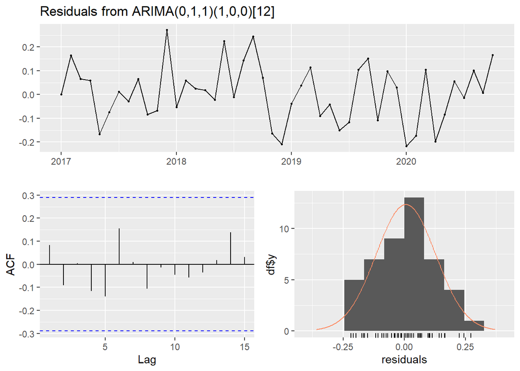

```
##
##  Ljung-Box test
##
## data:  Residuals from ARIMA(0,1,1)(1,0,0)[12]
## Q* = 4.5164, df = 7, p-value = 0.7187
##
## Model df: 2.   Total lags used: 9
```

```r
checkresiduals(model2_1)
```

```r
LjungBoxTest(residuals(model2_1), k = 2, lag.max = 20)
```

```
##   m    Qm    pvalue
##   1  0.34 0.5570974
##   2  0.76 0.3822075
##   3  0.76 0.3819200
##   4  1.47 0.4798350
##   5  2.51 0.4732006
##   6  3.85 0.4265483
##   7  3.86 0.5703761
##   8  4.51 0.6086030
##   9  4.52 0.7187472
##  10  4.64 0.7947866
##  11  4.85 0.8473904
##  12  4.93 0.8958786
##  13  4.95 0.9335178
##  14  6.28 0.9014327
##  15  6.35 0.9326656
##  16  9.67 0.7862334
##  17  9.75 0.8352838
##  18 10.40 0.8450241
##  19 10.57 0.8780181
##  20 11.32 0.8804716
```